# PCIT-CoS-Waitlist RCT Paper 1: SSP Insecurity

Nancy Briggs

2024-04-29

### SSP Insecurity

Output run on 2024-04-29

variables are SSP_Pre_three_way_secure_or_insecure & SSP_Post_three_way_secure_or_insecure

#### Descriptives

| group | time | 0 | pct0 | 1 | pct1 | total |
| --- | --- | --- | --- | --- | --- | --- |
| 1 | Pre | 11 | 0.379 | 18 | 0.621 | 29 |
| 2 | Pre | 19 | 0.655 | 10 | 0.345 | 29 |
| 3 | Pre | 18 | 0.621 | 11 | 0.379 | 29 |
| 1 | Post | 9 | 0.600 | 6 | 0.400 | 15 |
| 2 | Post | 3 | 0.750 | 1 | 0.250 | 4 |
| 3 | Post | 1 | NA | NA | NA | NA |

#### Model & Results

A generalized linear mixed model (GLMM) with random effect for individual and fixed effects of group, time and the interaction was run. A binomial distribution with logit link was specified. Odds ratios were obtained for group differences and change within group.

```
## fixed-effect model matrix is rank deficient so dropping 1 column / coefficient
```

[output not shown]

This is the ANOVA table for the model. p-values are likelihood ratio tests for adding the new term to the model just before. A p-value <0.05 indicates that adding that term results in better model fit. The most important p-value is the interaction p-value. Here, there is no evidence that the pattern of change over time is different among the groups (p=0.711).

```r
summary(result3)
```

```
## Generalized linear mixed model fit by maximum likelihood (Laplace
##   Approximation) [glmerMod]
##  Family: binomial  ( logit )
## Formula: outcome ~ group * time + (1 | id)
##    Data: dat
##
##      AIC      BIC   logLik deviance df.resid
##    150.8    166.8    -69.4    138.8      100
##
## Scaled residuals:
##     Min      1Q  Median      3Q     Max
## -1.2974 -0.7318 -0.6789  1.0899  1.6263
##
## Random effects:
##  Groups Name        Variance Std.Dev.
##  id     (Intercept) 0.2785   0.5277
## Number of obs: 106, groups:  id, 87
##
## Fixed effects:
##              Estimate Std. Error z value Pr(>|z|)
## (Intercept)    0.5275     0.4176   1.263   0.2064
## group2        -1.2141     0.6174  -1.966   0.0493 *
## group3        -1.0550     0.6046  -1.745   0.0810 .
## time2         -0.9393     0.6889  -1.363   0.1727
## group2:time2   0.5509     1.4687   0.375   0.7076
## ---
## Signif. codes:  0 '***' 0.001 '**' 0.01 '*' 0.05 '.' 0.1 ' ' 1
##
## Correlation of Fixed Effects:
##             (Intr) group2 group3 time2
## group2      -0.718
## group3      -0.724  0.547
## time2       -0.579  0.422  0.425
## group2:tim2  0.297 -0.417 -0.235 -0.488
## fit warnings:
## fixed-effect model matrix is rank deficient so dropping 1 column / coefficient
```

#### Estimated Means & Change

Estimated means for each Treatment and Time are presented. In addition, within-group change between time points is presented with 95% CIs.

##### Group ORs at each timepoint

Odds Ratios at Each Time Point

| Comparison | Time | OR | SE | z | p | adj p | Lower CL | Upper CL |
| --- | --- | --- | --- | --- | --- | --- | --- | --- |
| 1 / 2 | 1 | 3.367 | 2.079 | 1.966 | 0.121 | 0.148 | 0.792 | 14.314 |
| 1 / 3 | 1 | 2.872 | 1.736 | 1.745 | 0.189 | 0.243 | 0.696 | 11.845 |
| 2 / 3 | 1 | 0.853 | 0.496 | -0.273 | 0.960 | 1.000 | 0.218 | 3.335 |
| 1 / 2 | 2 | 1.941 | 2.592 | 0.497 | 0.873 | 1.000 | 0.085 | 44.361 |
| 1 / 3 | 2 | NA | NA | NA | NA | NA | NA | NA |
| 2 / 3 | 2 | NA | NA | NA | NA | NA | NA | NA |

In this table the OR is the effect size. No bootstrapping is needed.

##### Change within each group

Within-Group Change

| Comparison | Group | OR | SE | z | p | adj p | Lower CL | Upper CL |
| --- | --- | --- | --- | --- | --- | --- | --- | --- |
| 2 / 1 | 1 | 0.391 | 0.269 | -1.363 | 0.173 | 0.173 | 0.101 | 1.508 |
| 2 / 1 | 2 | 0.678 | 0.869 | -0.303 | 0.762 | 0.762 | 0.055 | 8.370 |
| 2 / 1 | 3 | NA | NA | NA | NA | NA | NA | NA |

These ORs now represent the odds of a 1 at time 2 relative to time 1 within group. Because there is only 1 comaprison within group, the adjusted pvalue is the same.

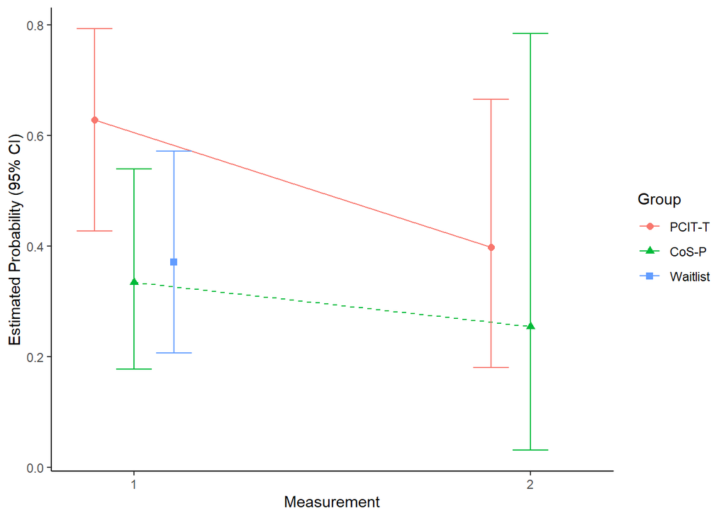

#### Hypothesis 2

##### Differene between G1 and G2, change from T1 to T3

```
## group = 1:
##  time   prob     SE  df asymp.LCL asymp.UCL
##  1     0.629 0.0974 Inf    0.4278     0.793
##  2     0.398 0.1347 Inf    0.1805     0.666
##
## group = 2:
##  time   prob     SE  df asymp.LCL asymp.UCL
##  1     0.335 0.0959 Inf    0.1779     0.539
##  2     0.254 0.2296 Inf    0.0309     0.785
##
## group = 3:
##  time   prob     SE  df asymp.LCL asymp.UCL
##  1     0.371 0.0975 Inf    0.2065     0.572
##  2    nonEst     NA  NA        NA        NA
##
## Confidence level used: 0.95
## Intervals are back-transformed from the logit scale
```

```
## group = 1:
##  contrast odds.ratio    SE  df asymp.LCL asymp.UCL
##  2 / 1         0.391 0.269 Inf    0.1013      1.51
##
## group = 2:
##  contrast odds.ratio    SE  df asymp.LCL asymp.UCL
##  2 / 1         0.678 0.869 Inf    0.0549      8.37
##
## group = 3:
##  contrast odds.ratio    SE  df asymp.LCL asymp.UCL
##  2 / 1        nonEst    NA  NA        NA        NA
##
## Confidence level used: 0.95
## Intervals are back-transformed from the log odds ratio scale
```

```
##
##   Simultaneous Tests for General Linear Hypotheses
##
## Fit: glmer(formula = outcome ~ group * time + (1 | id), data = dat,
##     family = binomial)
##
## Linear Hypotheses:
##        Estimate Std. Error z value Pr(>|z|)
## 1 == 0   0.5509     1.4687   0.375    0.708
## (Adjusted p values reported -- single-step method)
```

Change in G1 from T1 to T3: 0.391

Change in G2 from T1 to T3: 0.678

p=0.7084. We have no evidence that the change from T1 to T3 is different for G1 and G2

#### Residuals

Assumptions of the model are met.

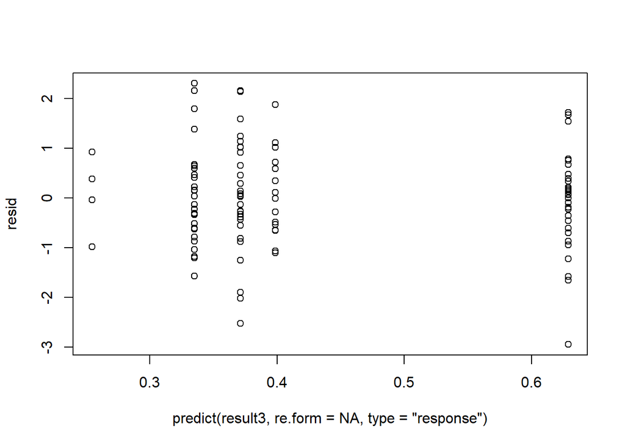

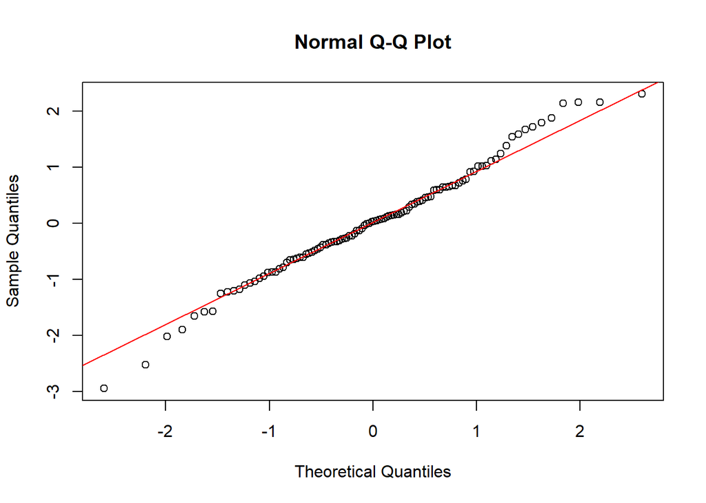

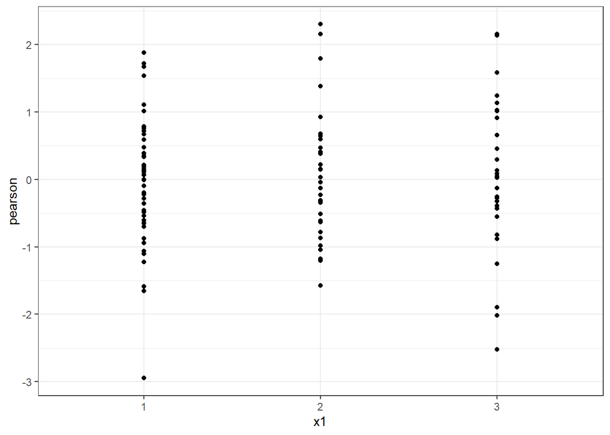

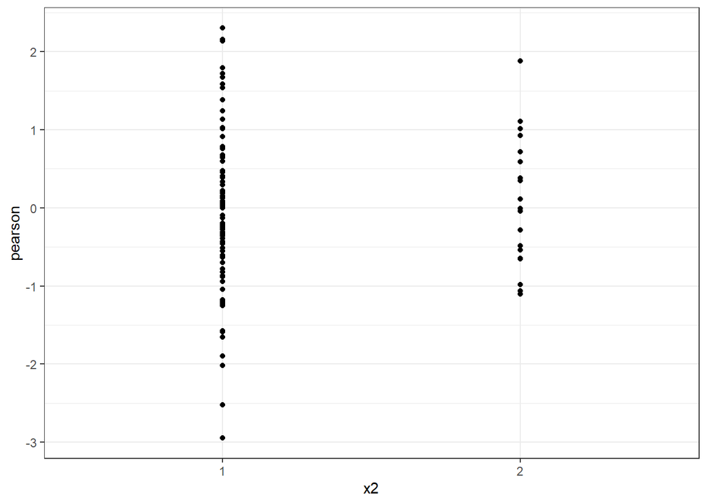

```r
rm(list = ls())
```